# Key2Enrich: An all-in-one R/Bioconductor package for gene list enrichment analysis and pathway visualization

Dong Wang

2017-11-20

## Abstract

Enrichment analysis is a popular method for analyzing gene sets generated from transcriptomes and proteomics. Here, we developed Key2Enrich, a novel all-in-one R package for gene set enrichment analysis. It combines the whole pipeline of enrichment analysis in one package, provides enrichment function and visualization methods, while it also maps and renders input sample data on relevant pathway graphs. Key2Enrich automatically downloads the pathway graph data, parses the data file, maps and integrates the genes of input data onto the pathway and renders pathway graphs. Currently, Key2Enrich supports three species, including human, mice and rat. Both enrichment analysis and pathway mapping functions can be integrated with other functional annotation tools for large-scale and fully automated analysis pipelines.

## Get started

```r
# Load sample data.
data(inputSample)
inputSample<-as.data.frame(inputSample)
head(inputSample)
```

```
##   entrezgene mgi_symbol    AveExpr         t     P.Value   adj.P.Val
## 1      11287        Pzp 2.69593062 -6.757840 0.000004050 0.002012964
## 2      11307      Abcg1 1.97717824  2.784741 0.013026655 0.265904983
## 3      11421        Ace 4.94231820 -5.209777 0.000079500 0.011166584
## 4      11425      Apoc4 0.18600701  3.533088 0.002676302 0.102649691
## 5      11438     Chrna4 8.00167645 -5.696547 0.000030100 0.006794465
## 6      11459      Acta1 0.06156938  3.604518 0.002297632 0.093422810
##           B    log2FC    ensembl_gene_id KEGG_GeneID
## 1  4.348853 -2.942068 ENSMUSG00000030359   mmu:11287
## 2 -3.655590  1.070545 ENSMUSG00000024030   mmu:11307
## 3  1.196776 -1.523758 ENSMUSG00000020681   mmu:11421
## 4 -2.239151  2.085652 ENSMUSG00000074336   mmu:11425
## 5  2.101928 -1.675116 ENSMUSG00000027577   mmu:11438
## 6 -1.947455  1.146258 ENSMUSG00000031972   mmu:11459
```

KEGG pathway enrichment analysis, this step will take some time, the data is getting from KEGG database by using KEGG API.

thisKEGGEnricherMatrix<-KEGGEnricherMatrixRealTime(inputSample,“mouse”,“fdr”,“fdr”,0.05) colnames(thisKEGGEnricherMatrix) head(thisKEGGEnricherMatrix[c(1:6,11:13)])

Then the result can be show in bar plot. Key2EnrichBarplot(thisKEGGEnricherMatrix,“KEGG”,15,20)

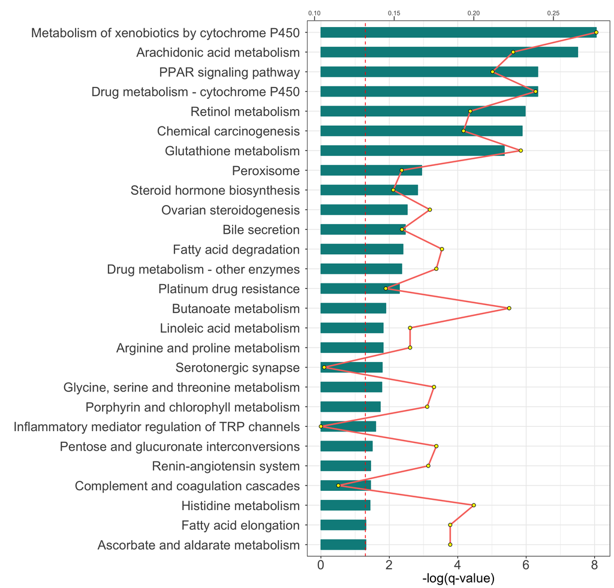

Signicantly enriched KEGG pathways

These step can be done by using one function. The figure sizes have been customised so that you can easily put two images side-by-side. The genes can mapped to the nodes of KEGG pathway by using the parameter ifMapOnPath=TRUE.

KEGGSigMx<-Key2KEGGEnrich(inputSample=inputSample,inputSpecies=“mouse”, adjustMethod=“fdr”,filterMethod=“fdr”, filterValue=0.05,ifbarplot=TRUE, ifMapOnPath=TRUE,type=“KEGG”, imgWidth=15,imgHeight=20) head(KEGGSigMx[c(1:6,11:13)])

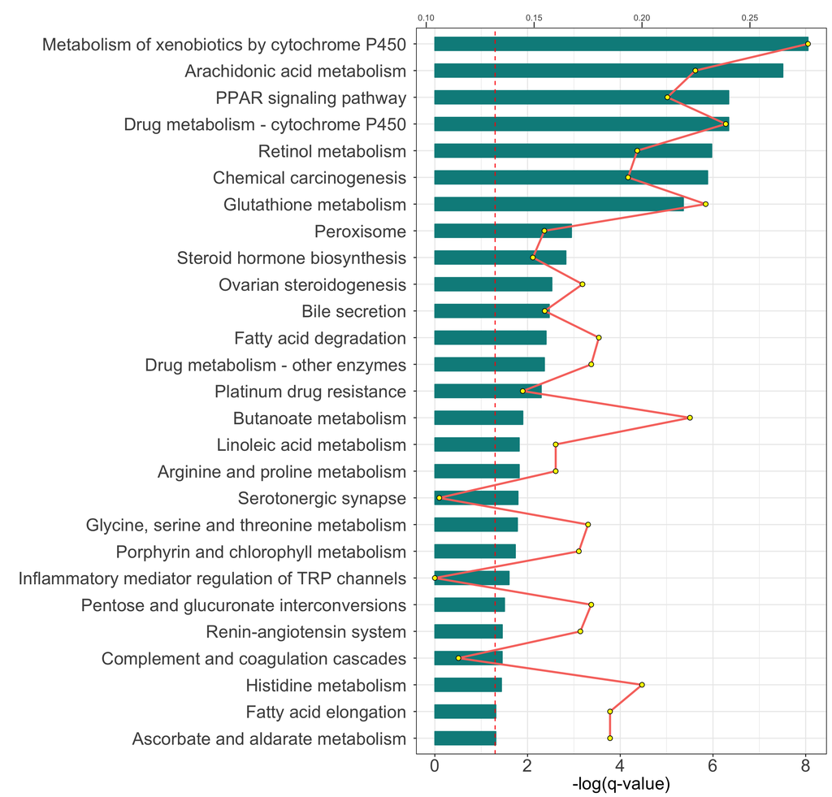

Signicantly enriched KEGG pathways

[figure not shown]

Map differential expressed genes on KEGG pathway

[figure not shown]

Map differential expressed genes on KEGG pathway

Enrichment analysis based on Reactome pathways. reactomePValueMatrix<-Reactome2Enrich(geneIDs=as.character(inputSample$entrezgene),“mouse”,“fdr”,0.05) colnames(reactomePValueMatrix) head(reactomePValueMatrix[,1:6])

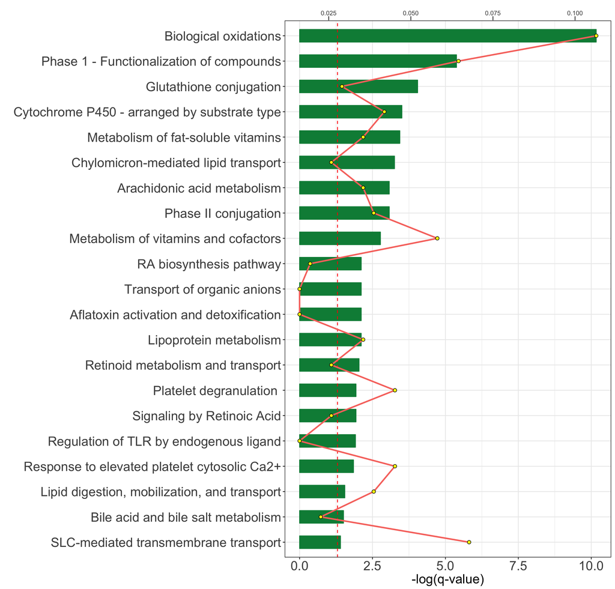

Signicantly enriched Reactome pathways

Enrichment analysis based on terms of gene ontology. egoDF<-GO2Enrich(geneIDs=as.character(inputSample$entrezgene),“mouse”,“fdr”,0.05,“CC”) colnames(egoDF) egoDF[,c(1:3,5:7)]

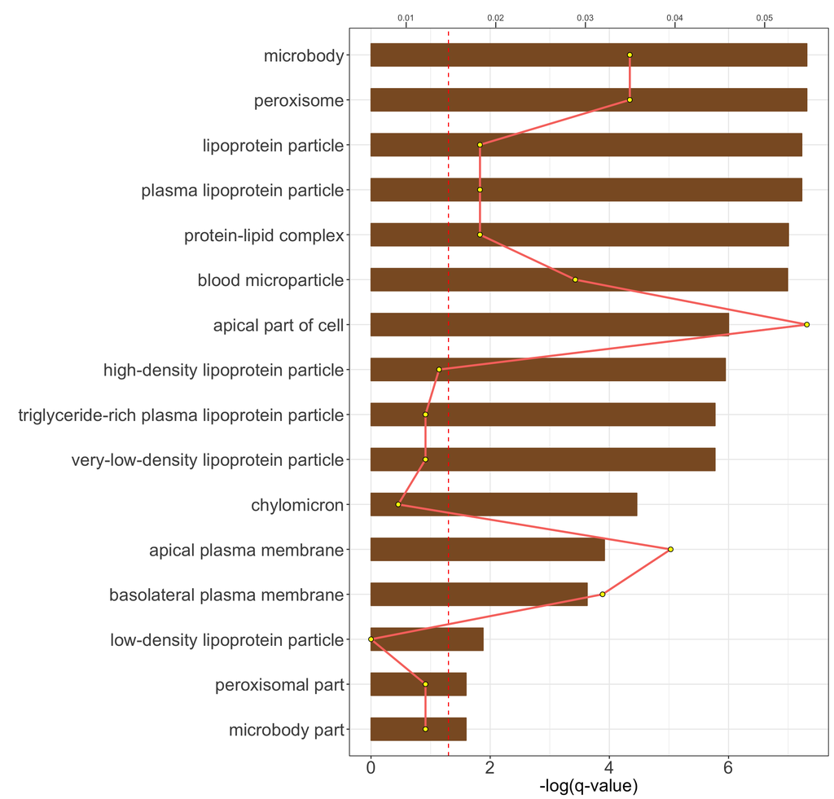

Signicantly enriched Cellular Component terms of gene ontology

## Functions can be called by other packages

The gene list can be mapped to specific KEGG pathway. Key2Enrich can intergate with other genome-wide data analysis tools or packages. mappingOnSpecifiedKEGGPathway(“mmu04976”,inputSample,“mouse”)

[figure not shown]

Map differential expressed genes on KEGG pathway

Get KEGG pathname and pathway ID of a specific species.

```r
mmuInfo<-getAllPathNameAndID("mmu")
head(mmuInfo)
```

```
##                                    pathName   pathID
## 1             Glycolysis / Gluconeogenesis  mmu00010
## 2                Citrate cycle (TCA cycle)  mmu00020
## 3                Pentose phosphate pathway  mmu00030
## 4 Pentose and glucuronate interconversions  mmu00040
## 5          Fructose and mannose metabolism  mmu00051
## 6                     Galactose metabolism  mmu00052
```

Get all KEGG gene ID and entrezgene ID of a specific species.

```r
mmuGeneInfo<-KEGGID2EntrezID("mmu")
head(mmuGeneInfo)
```

```
##     KEGG_GeneID entrezgene
## 1 mmu:100009600  100009600
## 2 mmu:100009609  100009609
## 3 mmu:100009614  100009614
## 4 mmu:100009664  100009664
## 5    mmu:100012     100012
## 6    mmu:100017     100017
```

Get all KEGG pathway name of a specific species.

```r
allMmuPath<-getTotalPathNames("mmu")
head(allMmuPath)
```

```
##   pathwayName
## 1    mmu00010
## 2    mmu00020
## 3    mmu00030
## 4    mmu00040
## 5    mmu00051
## 6    mmu00052
```

Calculate p-value and adjust p-value for a specific KEGG pathway on input sample.

```r
allGeneInPathwayDF<-getAllGeneInPathwayDF("mmu")
N<-getN(allGeneInPathwayDF)
n<-get_n(inputSample,allGeneInPathwayDF)

pValueMX<-getPValue("mmu00053","mmu",inputSample,N,n)
pValueMX[1:6]
```

```
##   pathName  M m    N   n      pValue
## 1 mmu00053 27 5 8119 332 0.004260783
```

Get all KEGG pathway ID and its corresponding gene list in KEGG gene ID format.

```r
pathIDandKEGG_geneID<-getAllGeneInPathwayDF("mmu")
head(pathIDandKEGG_geneID)
```

```
##          pathID   KEGG_GeneID
## 1 path:mmu00010 mmu:100042025
## 2 path:mmu00010    mmu:103988
## 3 path:mmu00010    mmu:106557
## 4 path:mmu00010    mmu:110695
## 5 path:mmu00010     mmu:11522
## 6 path:mmu00010     mmu:11529
```

Parse KEGG xml file.

```
path<-system.file(package = "Key2Enrich")
xmlPath<-paste(path,"/extdata",sep="")
xmlFile<-paste(xmlPath,sep="","/hsa04012.xml")
r<-parseKGMLFile(xmlFile)
kegg.nodes <- lapply(r[childIsEntry(r)], parseEntry)
nodeDF<-data.frame(KEGG_GeneID="NA",type=NA,link=NA,graphicName=NA,
                  graphicType=NA,graphicX=NA,graphicY=NA,
                  graphicWidth=NA,graphicHeight=NA)
nodeDF<-parseList2Dataframe(kegg.nodes,nodeDF)
head(nodeDF)
```

Key2Enrich support gene set identifiers in GSEABase class.

```r
data(gs)
library(GSEABase)
reactomePValueMatrix<-Reactome2Enrich(geneIds(gs),"mouse","fdr",0.05)

egoDF<-GO2Enrich(geneIds(gs),"mouse","fdr",0.05,"CC")
```